# Lesson 7 | The Effective Reproduction Number R<sub>e</sub>

# Introduction

The effective reproduction number, R<sub>e</sub>, is a key epidemiological metric used to assess the current potential of a disease to spread in a population. Unlike R<sub>0</sub>, which assumes a completely susceptible population, R<sub>e</sub> considers the ongoing dynamics of the population’s susceptibility.

# 1 Effective Reproduction Number (R<sub>e</sub>)

Despite its place at the forefront of mathematical epidemiology, the concept of R<sub>0</sub> has many flaws and defining it can be difficult. As noted in the previous lesson, R<sub>0</sub> is only appropriate under specific starting conditions at the beginning of an epidemic. Few epidemics are ever observed at the precise moment an infected individual enters a wholly susceptible population.

**Key limitation of R0**

As the disease spreads, the number of susceptible individuals decreases, and R<sub>0</sub> becomes an overestimate because the whole populations is no longer in the S category.

As the percentage of susceptibles decreases, there is a “wastage” of contact. In our deterministic model, the number of contacts per individual remains constant, but the probability of contact between S and I individuals is decreasing.

## 1.1 Differences between the basic reproduction number (R<sub>0</sub>) and effective reproduction number (R<sub>e</sub>)

**Basic reproduction number (R<sub>0</sub>)**

- Average number of people that one infected person can potentially go on to infect in an entirely susceptible population if there are no intervention measures in place.

**Effective reproduction number at a given time (R<sub>e</sub>)**

- Average number of secondary cases per one case at any given time in the epidemic.
- This number varies depending on effective control measures and behavioral changes (e.g., physical distancing, usage of face masks, self-isolation, or quarantine).
- Reflects real-time transmissibility of virus as the outbreak progresses

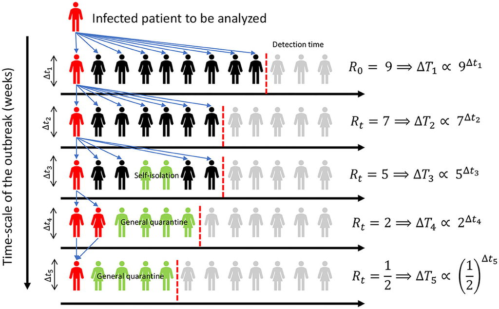

# 2 Mathematical derivation

## 2.1 Expression for R<sub>e</sub>

To calculate the effective reproduction number R<sub>e</sub>, it’s essential to recognize that it reflects the number of secondary infections produced by a typical infectious individual at *any given time* $t$ in a population where some individuals may no longer be susceptible.

R<sub>e</sub> scales with the proportion of susceptibles in the population, and can be expressed as:

$$R_e = R_0 \times \frac{S}{N}$$

Here:

- $R_0$ is the basic reproduction number.
- $S$ is the current number of susceptible individuals.
- $N$ is the total population size.

## 2.2 Derivation from SIR ODEs

### 2.2.1 Calculating R<sub>e</sub> for Density-Dependent Transmission

Theoretical Framework

Given the SIR model dynamics where:

- **S** = Susceptible individuals
- **I** = Infected individuals
- **R** = Recovered individuals

The rates of change in these compartments are governed by the following ordinary differential equations (ODEs):

$$\frac{dS}{dt} = -\beta S I, \quad \frac{dI}{dt} = \beta S I - \gamma I,
\quad \frac{dR}{dt} = \gamma I$$

Here, $\beta$ represents the transmission rate per contact and $\gamma$ represents the recovery rate.

Let’s consider a scenario where the disease is at a point where it has already infected some of the population, and thus not everyone is susceptible. To determine R<sub>e</sub>:

1. **Start with the expression for** $\frac{dI}{dt}$:

Given $\frac{dI}{dt} = \beta S I - \gamma I$, for the disease to persist in the population, $\frac{dI}{dt}$ must be greater than zero.

2. **Rearrange to highlight the infection terms**:

$$\beta S I - \gamma I > 0$$
$$\beta S I > \gamma I$$
Dividing all terms by $I$ (assuming $I > 0$):
$$\beta S > \gamma$$

3. **Isolate the susceptible ratio**:

Divide by $\gamma$ to find the condition under which the infection grows:

$$\frac{\beta S}{\gamma} > 1$$

4. **Relate to R<sub>0</sub>**:

Recognizing that $R_0 = \frac{\beta N}{\gamma}$ for density-dependent transmission, substitute to express in terms of $S$ and $N$:

$$\frac{\beta S}{\gamma} = R_0 \times
\frac{S}{N}$$

Thus, we have:

$$R_e = R_0 \times \frac{S}{N}$$

### 2.2.2 Calculating R<sub>e</sub> for Frequency-Dependent Transmission

For frequency-dependent transmission, the contact rate is adjusted for the population size, thereby making the transmission rate depend not just on the number of contacts an infected individual has, but also on the proportion of those contacts that are with susceptible individuals. This model is particularly relevant in large, mixed populations where the probability of contact between any two individuals is low.

In the case of frequency-dependent transmission, the transmission term is modified to $\frac{\beta S I}{N}$, reflecting that each infectious individual makes contact with a fraction of the population that is proportional to the total number of susceptible individuals divided by the total population size. The ODEs are:

$$\frac{dS}{dt} = -\frac{\beta S I}{N}, \quad \frac{dI}{dt} = \frac{\beta
S I}{N} - \gamma I, \quad \frac{dR}{dt} = \gamma I$$

Given the modified infection term, R<sub>e</sub> can be derived similarly by analyzing the growth condition of $\frac{dI}{dt}$:

1. **From the equation for** $\frac{dI}{dt}$:

$$\frac{\beta S I}{N} - \gamma I > 0$$

2. **Isolate the transmission terms**:

$$\frac{\beta S I}{N} > \gamma I$$

Dividing by $I$ and rearranging:

$$\frac{\beta S}{N} > \gamma$$

3. **Express in terms of R<sub>0</sub>**:

For frequency-dependent transmission, if we consider $R_0$ under initial conditions where $S \approx N$, then:

$$R_0 = \frac{\beta}{\gamma}$$

Thus, substituting back:

$$R_e = R_0 \times \frac{S}{N}$$

This calculation reaffirms that R<sub>e</sub>, like R<sub>0</sub>, diminishes as the proportion of susceptible individuals in the population decreases, but does so in a manner that is adjusted for the total population, which is crucial in densely populated or highly mixed environments.

### 2.2.3 Implications of R<sub>e</sub>

How does R<sub>e</sub> reflect the progression of an outbreak?

**R<sub>e</sub> > 1**

Each infected patient will go on to infect on average more than one person. Number of cases may increase exponentially over time.

**R<sub>e</sub> = 1**

Each infected patient will go on to infect one other person. Statistically, this would suggest that the outbreak is stabilizing, with no changes in number of infected people over time.

**R<sub>e</sub> < 1**

Each infected patient will go on to infect on average less than one person, meaning fewer people are being infected which suggests the outbreak is slowing down over time.

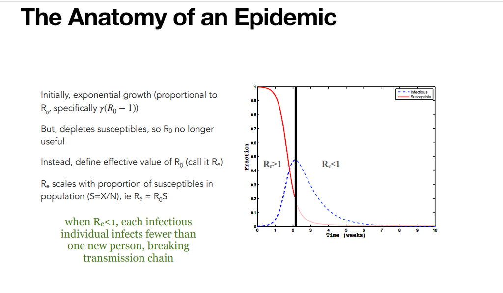

**Effective reproduction number at time (R<sub>e</sub>)**

R<sub>e</sub> is the average number of secondary cases per one case at any given time. This number will vary as the outbreak progresses, and indicates real-time transmissibility. Effective control measures and behavioral changes, such as quarantine enforcement, usage of face masks, travel restrictions, class suspensions, and social distancing, are all factors that may affect the Rt of a virus.

# 3 Critical population size S<sub>c</sub>

$$S_c = \frac{1}{R_0}$$

This threshold plays a key role in determining vaccination and control measures.

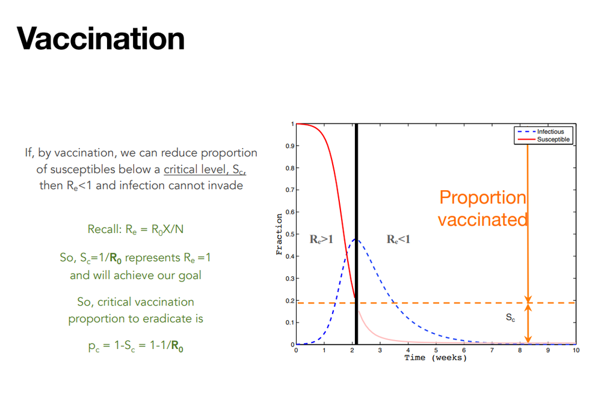

In the next lesson, we will go into detail about how to model different vaccination strategies.

# 4 Conclusion

R<sub>e</sub> effectively captures the current dynamics of disease transmission, reflecting changes in population susceptibility. It is a critical measure for understanding the control measures’ impact on an outbreak and determining strategies for intervention.